# RD Robustness Project

Exercise: Drop outside OBW

2021-03-18

# Introduction

The goal of this project is to test the robustness of the Regression-Discontinuity analysis to different extreme cases, via simulations, using the ‘rdrobust’ package.

## This Document: Excercise #1

Replacing observations outside Optimal Bandwitdh (OBW) with zeros, or dropping them.

### Set Parameters

Here we set the main parameters for the excercise:

```r
jump=10           # Size of jump at cutoff
loop=1000
figs.iter.save=5
quadratic=T       # T - quadratic DGP, F - linear
symm_obw="mserd"  # mserd - symmetric OBW, msetwo - asymmetric OBW
normal.x=T        # T - normal draws of x around cutoff, F - uniform draws
dgp.sd=3         # sd of normal noise added to DGP
bc=T              # bias-corrected estimates or conventional
pol.order=1       # polynomial order of local polynomial approx.
set.seed(123)
```

### Simulate DGP + Plot

```r
## dataframe for dgp
dt <- as.data.table(matrix(0,ncol=0,nrow=length(seq(-100,100,0.01))))
dt$x <- round(seq(-100,100,0.01), digits=2)
dt <- dt[x!=0]
dt$treated <- ifelse(dt$x>0,1,0)

dt$y.model <- 0.5*dt$x - 0.025*dt$x^2*quadratic + jump*dt$treated
dt$y=dt$y.model + rnorm(length(dt$x),0,dgp.sd)

## dataframe for draws (samples)
sample.x <- as.data.table(matrix(0, ncol = 0, nrow = nrow(dt)/10))
```

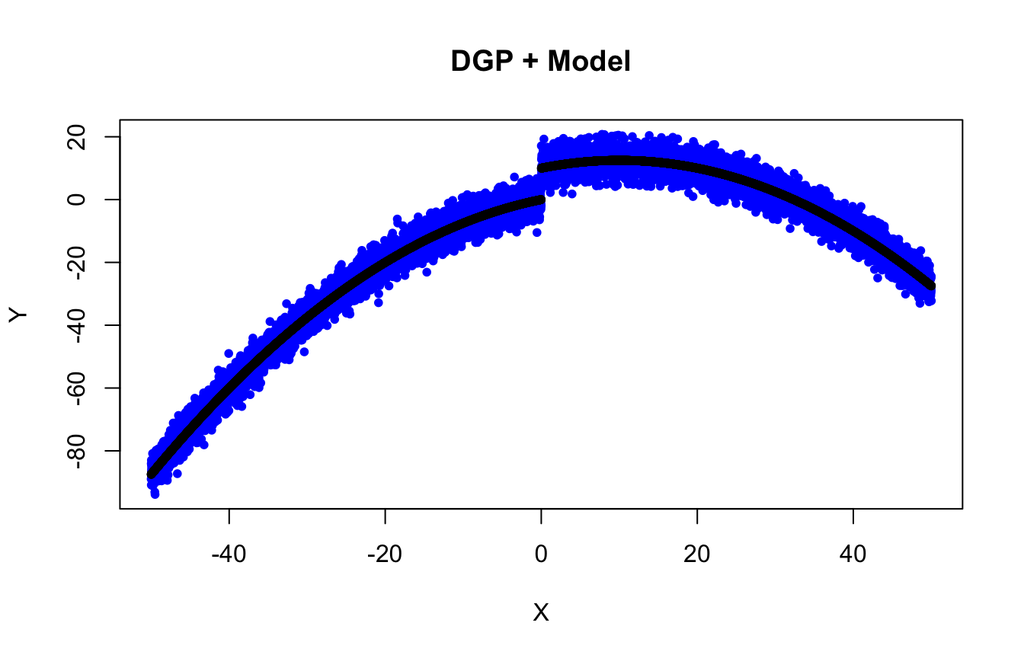

```r
### Plot DGP
dt[x %between% c(-50,50)] %T>%
  plot(y~x,., ylim = range(c(y,y.model)),
       pch=20, col="blue", ylab = "Y", xlab = "X") %T>%
  par(new = T) %>%
  plot(y.model~x,., ylim = range(c(y,y.model)),
       pch=20, axes = FALSE, xlab = "", ylab = "")
  title(main = "DGP + Model")
```

### Iterations

Running 1000 iterations, and saving figures from 5 last iterations to file. In each iteration, we:

1. draw randomly 2000 observations around the cutoff.
2. compute the OBW and RD coefficient.
3. drop observations outside OBW/replace them with zero
4. compute again the OBW and RD coefficient.

### Presenting figures from last iteration for illustration

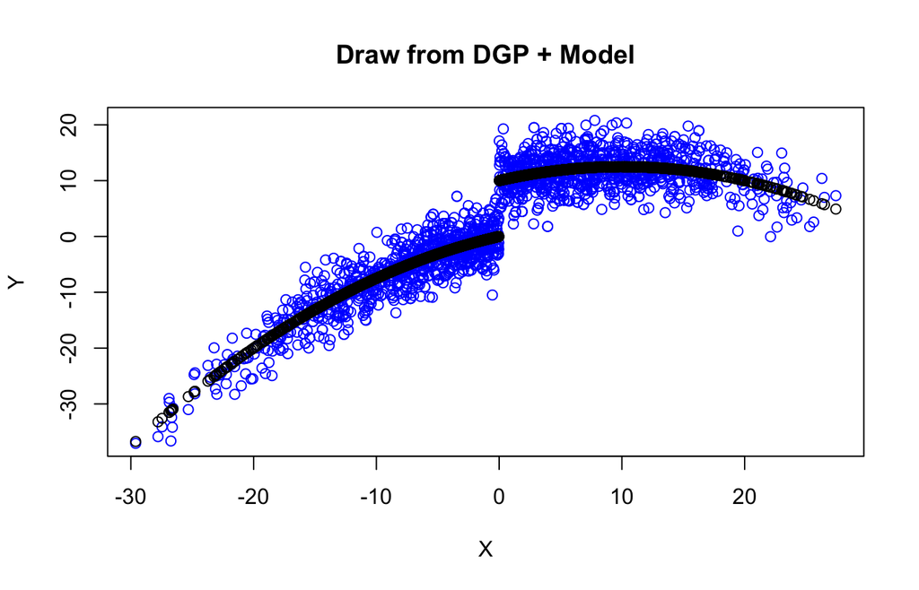

```
## [1] "Mass points detected in the running variable."
```

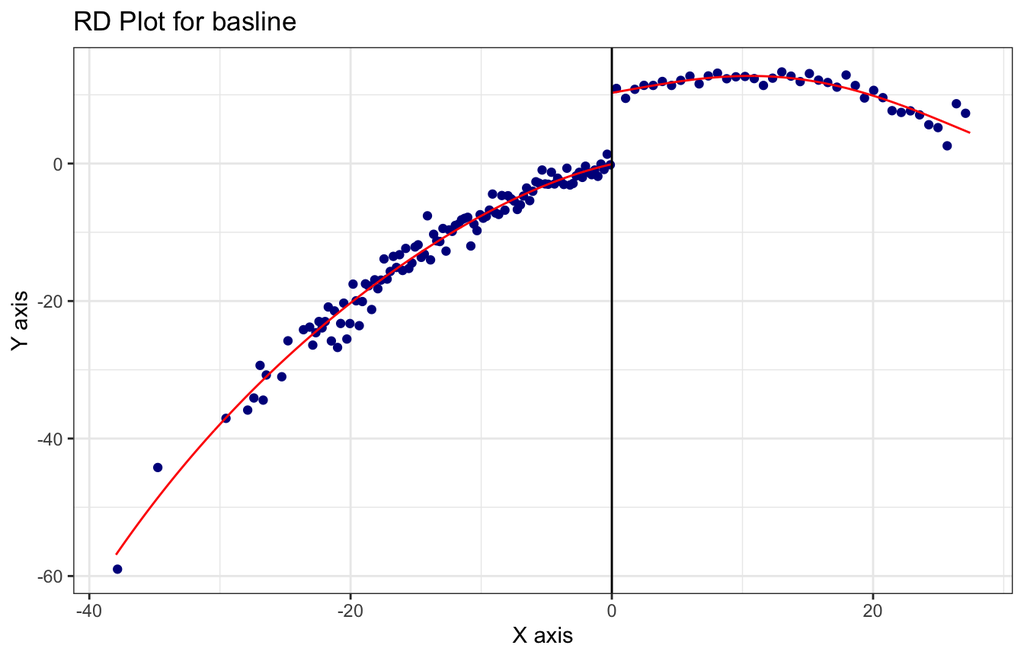

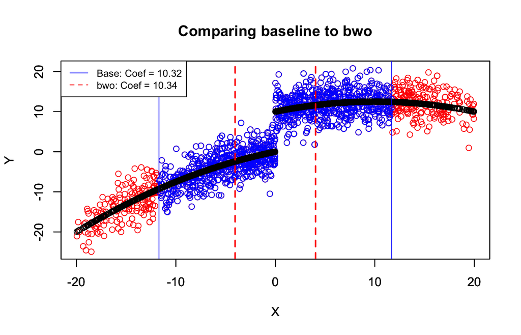

```
## [1] "Mass points detected in the running variable."
```

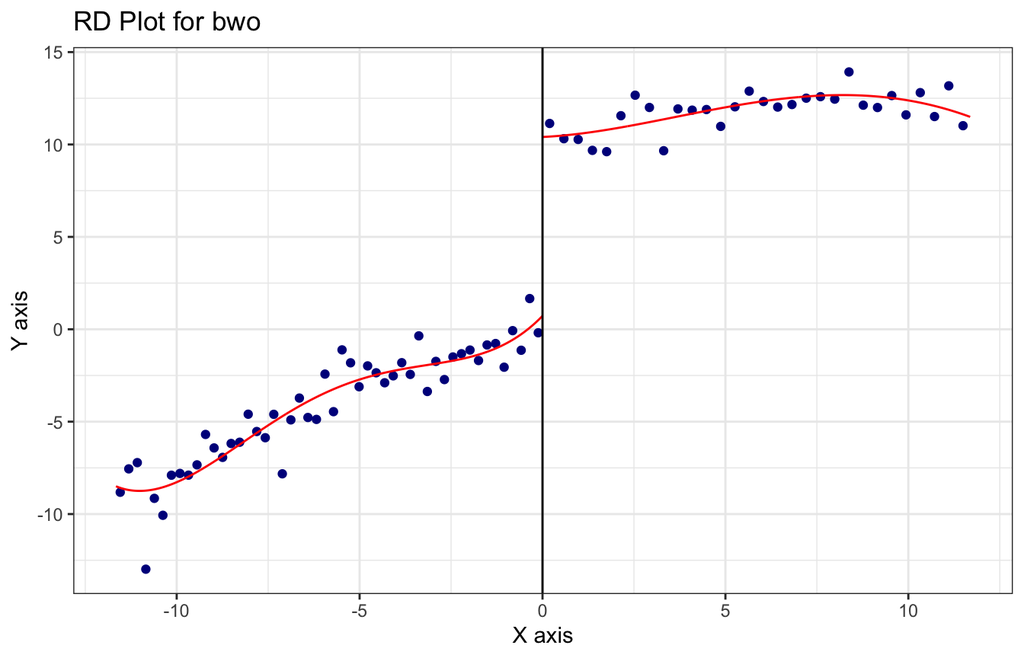

## Results

### Figures summarizing iterations

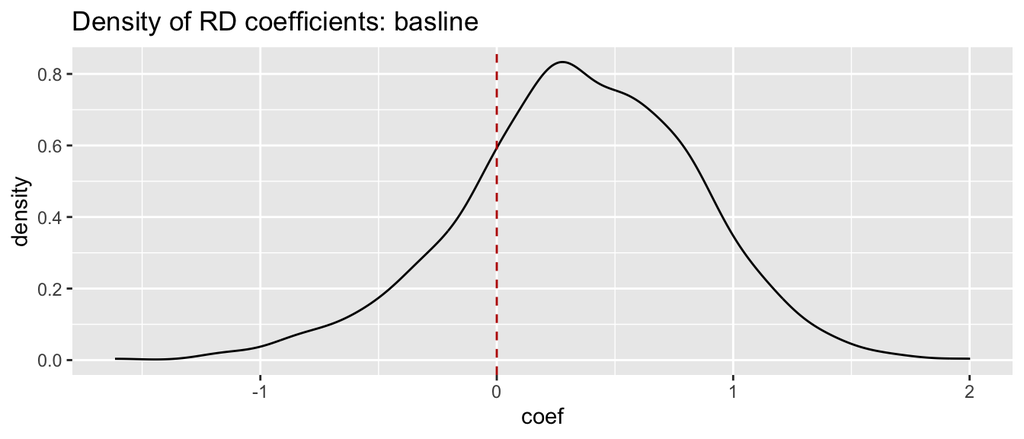

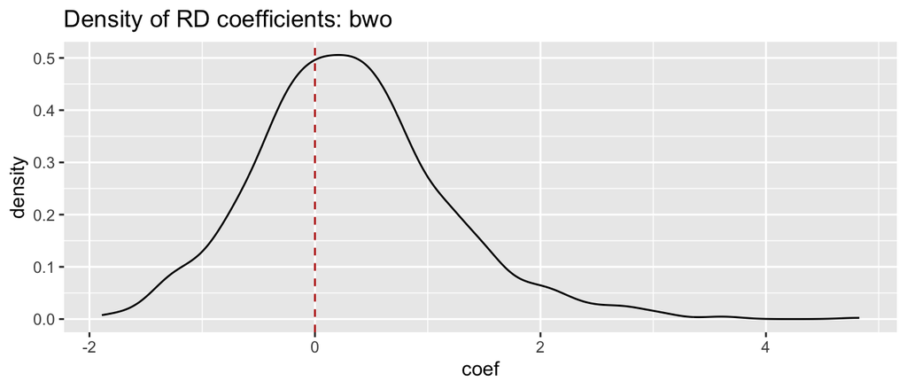

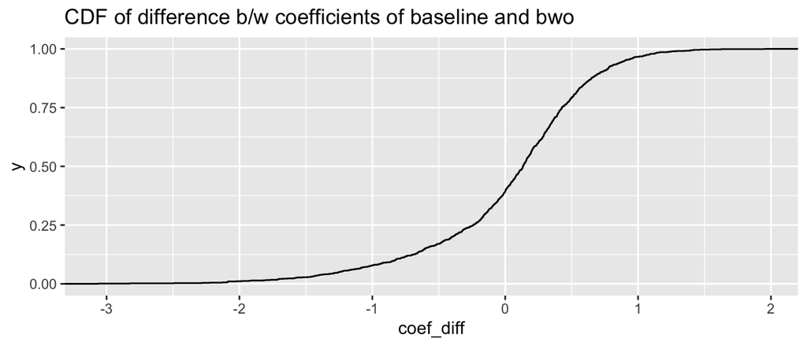

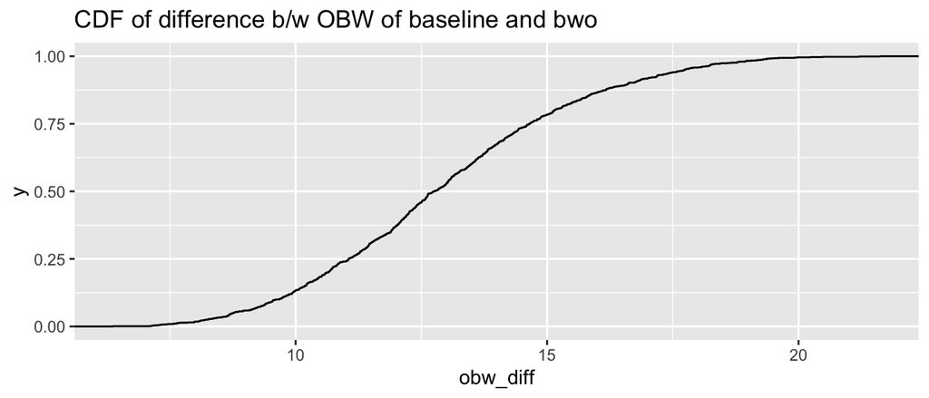

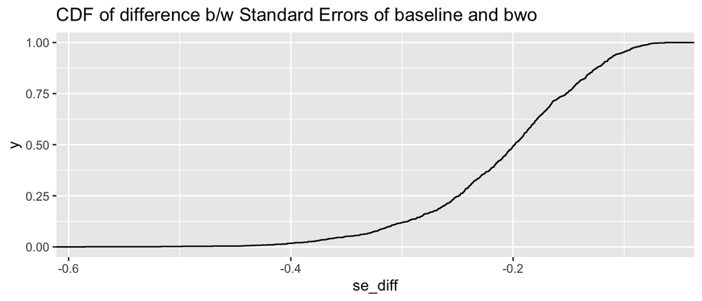

### Correlation between baseline OBW and change in OBW

```r
cor(results$obw,results.exercise$obw_diff)
```

```
## [1] 0.7464914
```

### Correlation between baseline coefficients and change in coefficients

```r
cor(results$coef,results.exercise$coef_diff)
```

```
## [1] -0.1075564
```

### Summary results - table:

Note: coefficient (treatment effects) are normalized to zero, by subtracting from each estimate the size of the jump at the cutoff.

```r
results_table=as.data.frame(matrix(0, ncol = 3, nrow = 3))
results_table[1,1]=round(mean(results$coef),digits = 4)
results_table[1,2]=round(mean(results.exercise$coef),digits = 4)
results_table[1,3]=round(mean(results.exercise$coef_diff),digits = 4)

results_table[2,1]=round(mean(results$obw),digits = 4)
results_table[2,2]=round(mean(results.exercise$obw),digits = 4)
results_table[2,3]=round(mean(results.exercise$obw_diff),digits = 4)

results_table[3,1]=round(mean(results$se),digits = 4)
results_table[3,2]=round(mean(results.exercise$se),digits = 4)
results_table[3,3]=round(mean(results.exercise$se_diff),digits = 4)

colnames(results_table) = c("base",exercise,"diff_base")
rownames(results_table) = c("coef","obw","se")


if (dgp.sd==1 & bc==F) {
  table_sd_1 <- results_table
} else if (dgp.sd==3 & bc==F) {
  table_sd_3 <- results_table
} else if (dgp.sd==5 & bc==F) {
  table_sd_5 <- results_table
} else if (bc==F) {
  table_sd_10 <- results_table
}

if (dgp.sd==1 & bc==T) {
  table_sd_1_bc <- results_table
} else if (dgp.sd==3 & bc==T) {
  table_sd_3_bc <- results_table
} else if (dgp.sd==5 & bc==T) {
  table_sd_5_bc <- results_table
} else if (bc==T) {
  table_sd_10_bc <- results_table
}
```

```r
bc_F <- rbind(table_sd_1,table_sd_3,table_sd_5,table_sd_10)
bc_T <- rbind(table_sd_1_bc,table_sd_3_bc,table_sd_5_bc,table_sd_10_bc)
full <- cbind(bc_F,bc_T)
rownames(full) <- c("coef(sd=1)", "obw(sd=1)", "se(sd=1)",
                    "coef(sd=3)", "obw(sd=3)", "se(sd=3)",
                    "coef(sd=5)", "obw(sd=5)", "se(sd=5)",
                    "coef(sd=10)", "obw(sd=10)", "se(sd=10)")
colnames(full) <- c("base(bc=F)", paste(exercise,"(bc=F)",sep=""),"diff_base(bc=F)",
                    "base(bc=T)", paste(exercise,"(bc=T)",sep=""),"diff_base(bc=T)")

# save(full, file = "rdsim_sd_bc_results.RData")
# load("rdsim_sd_bc_results.RData")
kable(full,"html") %>% kable_styling("striped") %>% save_kable(paste(figs.dir,"rdsim.png",sep = ""))

figure_name=paste(figs.dir,"rdsimplot1.png",sep = "")
png(figure_name)
plot(x=c(1,3,5,10), y=full[grep("coef", rownames(as.data.frame(full)),value=T),1]/jump,
     type="l",
     lwd=2,
     col="black",
     xlab="DGP Noise SD",
     ylab="Bias / Tau, Tau=10",
     main="RDRobust Bias Comparison")
lines(x=c(1,3,5,10), y=full[grep("coef", rownames(as.data.frame(full)),value=T),4]/jump,
      col="blue",
      lwd=2)
legend("topleft",legend=c("Conv. Baseline","Bias-Corr. Baseline"),
       col=c("black","blue"),
       lwd=2)
dev.off()

figure_name=paste(figs.dir,"rdsimplot2.png",sep = "")
png(figure_name)
plot(x=c(1,3,5,10), y=full[grep("coef", rownames(as.data.frame(full)),value=T),1]/jump,
     type="l",
     lwd=2,
     col="black",
     xlab="DGP Noise SD",
     ylab="Bias / Tau, Tau=10",
     main="RDRobust Bias Comparison")
lines(x=c(1,3,5,10), y=full[grep("coef", rownames(as.data.frame(full)),value=T),2]/jump,
      col="red",
      lwd=2)
legend("topleft",legend=c("Conv. Baseline","Conv. BWO"),
       col=c("black","red"),
       lwd=2)
dev.off()

figure_name=paste(figs.dir,"rdsimplot3.png",sep = "")
png(figure_name)
plot(x=c(1,3,5,10), y=full[grep("coef", rownames(as.data.frame(full)),value=T),4]/jump,
     type="l",
     lwd=2,
     col="blue",
     xlab="DGP Noise SD",
     ylab="Bias / Tau, Tau=10",
     main="RDRobust Bias Comparison")
lines(x=c(1,3,5,10), y=full[grep("coef", rownames(as.data.frame(full)),value=T),5]/jump,
      col="red",
      lwd=2)
legend("topleft",legend=c("Bias-Corr. Baseline","Bias-Corr. BWO"),
       col=c("blue","red"),
       lwd=2)
dev.off()

# beepr::beep(3)
```

### Interpreting results

When dropping values outside OBW, the new OBW are smaller, and the estimated coefficients are biased.

### Sensitivity Analysis to Noise-to-Signal Ratio

Finally, in order to put our results into context, we run a sensitivity analysis to analyze the degree to which the results are affected or driven by the noise-to-signal ratio. The ratio we refer to, here, is the size of the standard deviation of the error term that is added to the true underlying mean function for $Y$ relative to the true treatment effect size (size of the discontinuity, $\tau$).

One can observe that the bias ratio monotonically increases with increased noise, which is not too surprising. The first plot compares the results for the baseline case, where data is not dropped right outside the optimally selected bandwidth, while the second plot shows what happens when the data outside the initially selected bandwidth is removed (as a theoretical sensitivity exercise).

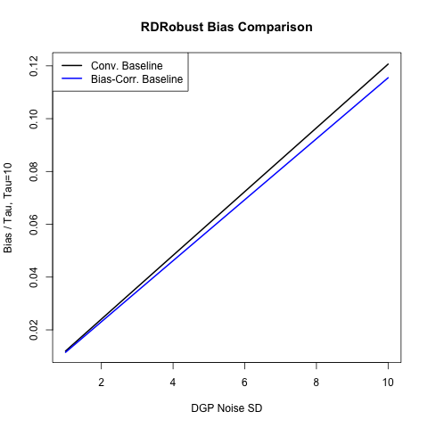

The effect of trimming the data is quite severe on the estimation, but once using the bias-corrected method suggsted by `rdrobust`, one can see that much of the bias disappears. Furthermore, the bias/tau ratio is quite small (falling within 1-10% of the treatment effect size). It is interesting to see that the bias-corrected estimates actually perform better when the data is trimmmed for our simple quadratic DGP than when we have the full dataset.

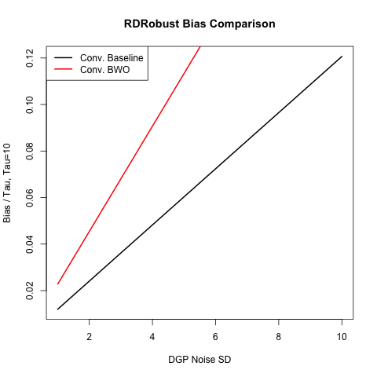

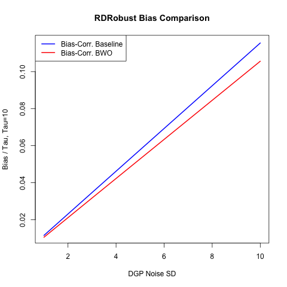

We finally report the results in a table (which are depicted in the graphs above).

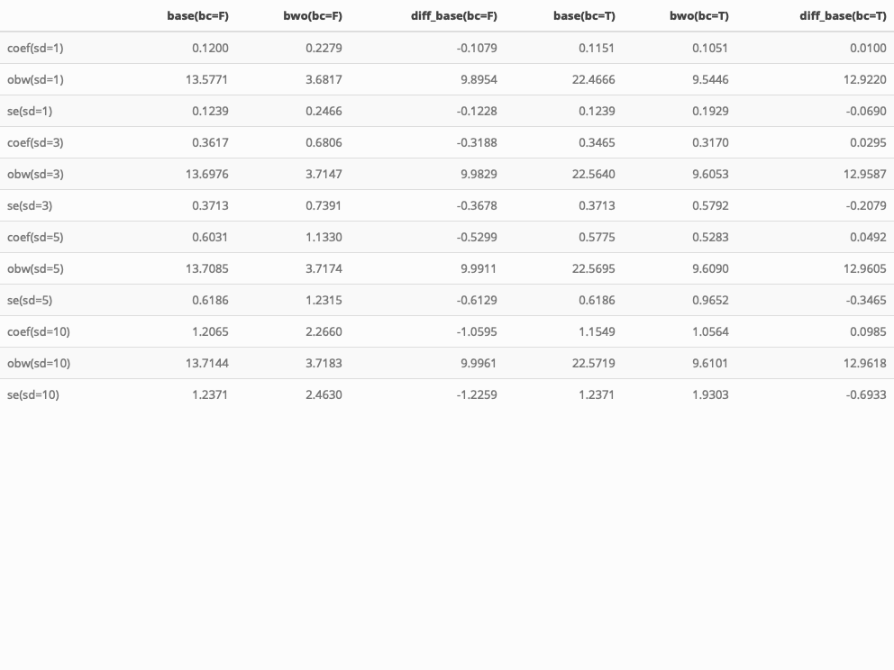

### References

1. Imbens, G., Kalyanaraman, K., July 2012. Optimal Bandwidth Choice for the Regression Discontinuity Estimator, The Review of Economic Studies, Volume 79, Issue 3, Pages 933–959.
2. Calonico, S., Cattaneo, M., Farrell, M. & Titiunik, R., July 2019. Regression Discontinuity Designs Using Covariates, The Review of Economics and Statistics, MIT Press, vol. 101(3), pages 442-451.
3. Lee, D., Randomized Experiments from Non-random Selection in U.S. House Elections, February 2008. Journal of Econometrics, 142, 675-697.